# Southeast Texas Flood Governance

SETx Mapping: Cognitive and Governance Networks

R. Patrick Bixler/LBJ School of Public Affairs

2024-02-13

### Analytical background

Files that we are importing into this document come from analytical work from the “V3.2_SETx Network Analysis.qmd”…this markdown file loads in Qualtrics API data from V2.

# Project Background.

This research utilized qualitative and survey data collection methods to better understand how governance actors address flood vulnerability in Southeast Texas. Thematic coding of interview transcripts were used to create fuzzy cognitive maps (FCMs) via Miro. The data collected via survey’s were used to create governance network maps of organizations and their relationships between each other addressing different flood-related issues

# SETx Survey Analysis

## Perceived drivers and impact of flooding

Perceived drivers and impact of flooding.

This code sets a descriptive bar chart of the average responses to “drivers of flooding”.

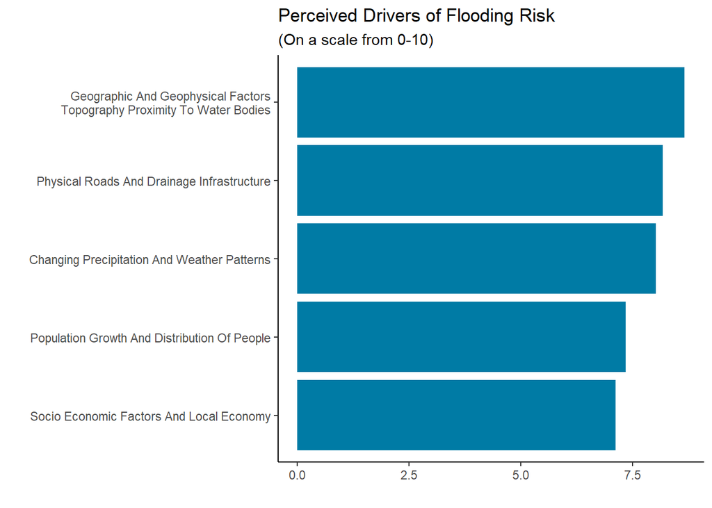

This code sets a descriptive bar chart of the average responses to “impacts of flooding.”

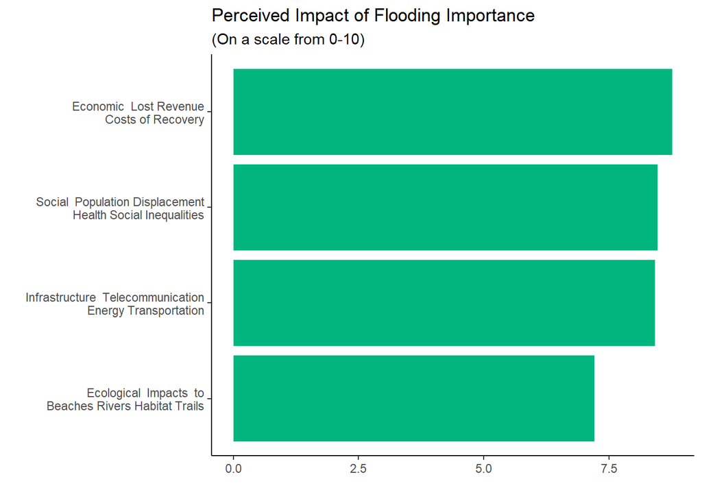

# SETx Network Map and Centrality Analysis

## SETx Network - All Issues

Considering the past 2 years, whom you go to flood-related meetings (virtually or in-person), receive or share advice or information, or implement projects within or across the Southeast Texas region.

### SETx Network-Network Viz-All Issues

[interactive chart not shown]

### SETx Network-Whole network stats-All Issues

| Network Statistic | Value |
| --- | --- |
| Total Node | 59.000 |
| Total Ties | 437.000 |
| Average Ties per Org | 7.407 |
| Mutual Nodes (Pairs of vertices with two directed edges) | 31.000 |
| Assymetric Nodes (Pairs of vertices with one directed edge) | 375.000 |
| Unconnected Nodes (Pairs of vertices with no directed edges) | 1305.000 |
| Reciprocity | 0.142 |
| Density | 0.128 |
| Transitivity | 0.387 |
| Centralization | 0.273 |

### SETx Network-Node level stats-All Issues

| name | inDegree1 | outDegree1 | TotalDegree | betweenness1 | inCloseness1 | outCloseness1 | label | org_type | precip | precip.1 | topography | infrastructure_driver | pop_growth | socio_economic | ecological | economic | infrastructure_impact | social_equity |
| --- | --- | --- | --- | --- | --- | --- | --- | --- | --- | --- | --- | --- | --- | --- | --- | --- | --- | --- |
| Texas General Land Office | 22 | 24 | 46 | 0.0677195 | 0.7894737 | 0.7307692 | Texas General Land Office | State agency | NA | 8 | 10 | 9 | 9 | 4 | 7 | 7 | 10 | 7 |
| National Weather Service Lake Charles Office | 18 | 21 | 39 | 0.0387009 | 0.7142857 | 0.6666667 | National Weather Service Lake Charles Office | Federal agency | NA | 8 | 8 | 9 | 9 | 10 | 7 | 8 | 8 | 10 |
| American Red Cross | 9 | 23 | 32 | 0.0373334 | 0.5660377 | 0.7037037 | American Red Cross | Nonprofit | 9 | 9 | 7 | 7 | 9 | 10 | 5 | 8 | 10 | 10 |
| Lamar University | 19 | 19 | 38 | 0.0272246 | 0.6976744 | 0.6666667 | Lamar University | Academia | 9 | 9 | 9 | 9 | 4 | 4 | 7 | 9 | 10 | 8 |
| The National Weather Service Houston Galveston Office | 13 | 12 | 25 | 0.0249726 | 0.6250000 | 0.5846154 | The National Weather Service Houston Galveston Office | Federal agency | NA | 8 | 8 | 10 | 9 | 10 | 5 | 7 | 10 | 10 |
| Lower Neches Valley Authority | 16 | 18 | 34 | 0.0234816 | 0.6666667 | 0.6551724 | Lower Neches Valley Authority | State agency | 8 | 8 | 10 | 4 | 7 | 4 | 9 | 10 | 9 | 7 |
| Us Geological Survey | 14 | 17 | 31 | 0.0182067 | 0.6382979 | 0.6031746 | Us Geological Survey | Nonprofit | NA | 10 | 8 | 7 | 9 | 5 | 7 | 7 | 8 | 10 |
| Floodplain Administrator Jasper County | 5 | 31 | 36 | 0.0157535 | 0.5084746 | 0.8444444 | Floodplain Administrator Jasper County | County agency | NA | 7 | 10 | 9 | 9 | 4 | 6 | 8 | 10 | 6 |
| Jefferson County Drainage District 6 | 16 | 12 | 28 | 0.0097324 | 0.6521739 | 0.5277778 | Jefferson County Drainage District 6 | County agency | 10 | 10 | 10 | 10 | 3 | 10 | 10 | 10 | 7 | 9 |
| Jefferson County Drainage District 7 | 15 | 14 | 29 | 0.0053300 | 0.6382979 | 0.5846154 | Jefferson County Drainage District 7 | County agency | 8 | 8 | 10 | 10 | 8 | 5 | 8 | 10 | 9 | 10 |
| Orange County Drainage District | 11 | 15 | 26 | 0.0037412 | 0.5882353 | 0.5937500 | Orange County Drainage District | County agency | 8 | 8 | 6 | 7 | 6 | 3 | 3 | 5 | 6 | 9 |
| Floodplain Administrator Chambers County | 2 | 12 | 14 | 0.0005675 | 0.4761905 | 0.5588235 | Floodplain Administrator Chambers County | County agency | NA | 10 | 9 | 9 | 6 | 5 | 7 | 8 | 8 | 10 |
| Floodplain Administrator Hardin County | 7 | 3 | 10 | 0.0003759 | 0.5254237 | 1.0000000 | Floodplain Administrator Hardin County | County agency | NA | 10 | 8 | 8 | 3 | 9 | 6 | 9 | 7 | 10 |
| Texas Division Of Emergency Management | 29 | 0 | 29 | 0.0000000 | 0.8918919 | NaN | Texas Division Of Emergency Management | State agency | NA | 7 | 8 | 8 | 0 | 4 | 5 | 7 | 7 | 9 |
| Army Corps Of Engineers | 25 | 0 | 25 | 0.0000000 | 0.8378378 | NaN | Army Corps Of Engineers | Federal agency | NA | 10 | 10 | 8 | 7 | 7 | 10 | 10 | 10 | 10 |

### SETx Network-Network composition-All Issues

| org_type | count | composition_pct | DegreeMean | IndegreeMean | BetweennessMean |
| --- | --- | --- | --- | --- | --- |
| County agency | 18 | 30.50847 | 12.88889 | 7.333333 | 0.0019723 |
| State agency | 17 | 28.81356 | 16.23529 | 11.000000 | 0.0053648 |
| Nonprofit | 11 | 18.64407 | 12.72727 | 2.181818 | 0.0050491 |
| Federal agency | 7 | 11.86441 | 18.57143 | 10.714286 | 0.0090962 |
| Academia | 2 | 3.38983 | 23.50000 | 9.500000 | 0.0136123 |
| Municipal | 2 | 3.38983 | 9.00000 | 0.000000 | 0.0000000 |
| Other | 2 | 3.38983 | 15.50000 | 0.000000 | 0.0000000 |

# SETx Prepare and Mitigate

Now that we’ve run this for the full “collab” model, let’s repeat for the prepare model

### SETx Network-Network Viz-Prepare and Mitigate

[interactive chart not shown]

### SETx Network-Whole network stats-Prepare and Mitigate

| Network Statistic | Value |
| --- | --- |
| Total Node | 57.000 |
| Total Ties | 353.000 |
| Average Ties per Org | 6.193 |
| Mutual Nodes (Pairs of vertices with two directed edges) | 18.000 |
| Assymetric Nodes (Pairs of vertices with one directed edge) | 317.000 |
| Unconnected Nodes (Pairs of vertices with no directed edges) | 1261.000 |
| Reciprocity | 0.102 |
| Density | 0.111 |
| Transitivity | 0.336 |
| Centralization | 0.224 |

### SETx Network-Nodel level stats-Prepare and Mitigate

| name | inDegree1 | outDegree1 | TotalDegree | betweenness1 | inCloseness1 | outCloseness1 |
| --- | --- | --- | --- | --- | --- | --- |
| National Weather Service Lake Charles Office | 16 | 21 | 37 | 0.0861824 | 0.6829268 | 0.6851852 |
| Lamar University | 16 | 16 | 32 | 0.0498404 | 0.5957447 | 0.6271186 |
| American Red Cross | 8 | 20 | 28 | 0.0431331 | 0.4444444 | 0.6491228 |
| Floodplain Administrator Jasper County | 4 | 27 | 31 | 0.0410741 | 0.4745763 | 0.7708333 |
| The National Weather Service Houston Galveston Office | 9 | 13 | 22 | 0.0366558 | 0.4516129 | 0.5873016 |
| Texas Water Development Board | 19 | 11 | 30 | 0.0290801 | 0.7368421 | 0.3894737 |
| Lower Neches Valley Authority | 12 | 7 | 19 | 0.0189205 | 0.5957447 | 0.4805195 |
| Jefferson County Drainage District 6 | 12 | 13 | 25 | 0.0186878 | 0.5714286 | 0.5285714 |
| Jefferson County Drainage District 7 | 10 | 15 | 25 | 0.0115774 | 0.5490196 | 0.5441176 |
| Orange County Drainage District | 7 | 14 | 21 | 0.0066856 | 0.5185185 | 0.5285714 |
| Floodplain Administrator Chambers County | 1 | 6 | 7 | 0.0013636 | 0.3783784 | 0.4625000 |
| Floodplain Administrator Hardin County | 5 | 3 | 8 | 0.0003057 | 0.4516129 | 0.2960000 |
| Texas Division Of Emergency Management | 22 | 0 | 22 | 0.0000000 | 0.7894737 | NaN |
| Army Corps Of Engineers | 21 | 0 | 21 | 0.0000000 | 0.7837838 | NaN |
| Texas General Land Office | 17 | 0 | 17 | 0.0000000 | 0.7073171 | NaN |

### SETx Network-Network composition-Prepare and Mitigate

| org_type | count | composition_pct | DegreeMean | IndegreeMean | BetweennessMean |
| --- | --- | --- | --- | --- | --- |
| County agency | 17 | 29.824561 | 11.00000 | 5.647059 | 0.0046879 |
| State agency | 17 | 29.824561 | 12.05882 | 9.411765 | 0.0028236 |
| Nonprofit | 10 | 17.543860 | 10.80000 | 1.700000 | 0.0043133 |
| Federal agency | 7 | 12.280702 | 17.00000 | 9.142857 | 0.0175483 |
| Academia | 2 | 3.508772 | 21.00000 | 8.000000 | 0.0249202 |
| Municipal | 2 | 3.508772 | 8.00000 | 0.000000 | 0.0000000 |
| Other | 2 | 3.508772 | 14.50000 | 0.000000 | 0.0000000 |

# SETx Respond, Recovery, Rebuild

Who do you work with to respond, recover, or rebuild?

### SETx Network-Network Viz-Respond/Recover/Rebuild

[interactive chart not shown]

### SETx Network-Whole network stats-Respond/Recover/Rebuild

| Network Statistic | Value |
| --- | --- |
| Total Node | 56.000 |
| Total Ties | 293.000 |
| Average Ties per Org | 5.232 |
| Mutual Nodes (Pairs of vertices with two directed edges) | 9.000 |
| Assymetric Nodes (Pairs of vertices with one directed edge) | 275.000 |
| Unconnected Nodes (Pairs of vertices with no directed edges) | 1256.000 |
| Reciprocity | 0.061 |
| Density | 0.095 |
| Transitivity | 0.291 |
| Centralization | 0.153 |

### SETx Network-Nodel level stats-Respond/Recover/Rebuild

| name | inDegree1 | outDegree1 | TotalDegree | betweenness1 | inCloseness1 | outCloseness1 |
| --- | --- | --- | --- | --- | --- | --- |
| National Weather Service Lake Charles Office | 7 | 20 | 27 | 0.0712738 | 0.4693878 | 0.6862745 |
| Lower Neches Valley Authority | 11 | 9 | 20 | 0.0533670 | 0.6571429 | 0.4375000 |
| Texas Water Development Board | 15 | 10 | 25 | 0.0510550 | 0.7419355 | 0.3500000 |
| Jefferson County Drainage District 7 | 8 | 15 | 23 | 0.0471380 | 0.5476190 | 0.5737705 |
| Jefferson County Drainage District 6 | 11 | 13 | 24 | 0.0467845 | 0.5897436 | 0.5555556 |
| Lamar University | 13 | 12 | 25 | 0.0337795 | 0.5476190 | 0.4929577 |
| Floodplain Administrator Jasper County | 3 | 14 | 17 | 0.0281987 | 0.3382353 | 0.5833333 |
| American Red Cross | 7 | 11 | 18 | 0.0171829 | 0.3048780 | 1.0000000 |
| Orange County Drainage District | 6 | 9 | 15 | 0.0070932 | 0.4893617 | 0.3017241 |
| The National Weather Service Houston Galveston Office | 2 | 13 | 15 | 0.0057099 | 0.2674419 | 0.5833333 |
| Floodplain Administrator Chambers County | 1 | 5 | 6 | 0.0033782 | 0.3770492 | 0.2892562 |
| Floodplain Administrator Hardin County | 4 | 3 | 7 | 0.0003591 | 0.3650794 | 0.2777778 |
| Texas Division Of Emergency Management | 22 | 0 | 22 | 0.0000000 | 0.8235294 | NaN |
| Army Corps Of Engineers | 18 | 0 | 18 | 0.0000000 | 0.7812500 | NaN |
| Texas General Land Office | 16 | 0 | 16 | 0.0000000 | 0.7222222 | NaN |

### SETx Network-Network Composition-Respond/Recover/Rebuild

| org_type | count | composition_pct | DegreeMean | IndegreeMean | BetweennessMean |
| --- | --- | --- | --- | --- | --- |
| County agency | 17 | 30.357143 | 9.294118 | 5.176471 | 0.0078207 |
| State agency | 17 | 30.357143 | 10.941176 | 8.117647 | 0.0061425 |
| Nonprofit | 11 | 19.642857 | 7.727273 | 1.272727 | 0.0015621 |
| Federal agency | 6 | 10.714286 | 12.833333 | 6.666667 | 0.0128306 |
| Academia | 2 | 3.571429 | 17.500000 | 6.500000 | 0.0168897 |
| Other | 2 | 3.571429 | 15.500000 | 0.000000 | 0.0000000 |
| Municipal | 1 | 1.785714 | 14.000000 | 0.000000 | 0.0000000 |

# Prepare and Mitigate - Issue Networks

## Prepare and mitigate - Precipitation and Weather

Who do you work with to prepare for and mitigate the following drivers of flooding of importance to you/your organization? - Changing precipitation and weather patterns

### Precipitation/Weather-Network Viz-Prepare

[interactive chart not shown]

### Precipitation/Weather-Whole network stats-Prepare

| Network Statistic | Value |
| --- | --- |
| Total Node | 55.000 |
| Total Ties | 160.000 |
| Average Ties per Org | 2.909 |
| Mutual Nodes (Pairs of vertices with two directed edges) | 1.000 |
| Assymetric Nodes (Pairs of vertices with one directed edge) | 158.000 |
| Unconnected Nodes (Pairs of vertices with no directed edges) | 1326.000 |
| Reciprocity | 0.013 |
| Density | 0.054 |
| Transitivity | 0.120 |
| Centralization | 0.134 |

### Precipitation/Weather-Node level stats-Prepare

| name | inDegree1 | outDegree1 | TotalDegree | betweenness1 | inCloseness1 | outCloseness1 |
| --- | --- | --- | --- | --- | --- | --- |
| The National Weather Service Houston Galveston Office | 8 | 12 | 20 | 0.0482763 | 1.0000000 | 0.6875000 |
| American Red Cross | 1 | 19 | 20 | 0.0262055 | 0.5333333 | 0.8800000 |
| Jefferson County Drainage District 6 | 4 | 12 | 16 | 0.0129280 | 1.0000000 | 0.8333333 |
| Jefferson County Drainage District 7 | 4 | 6 | 10 | 0.0059981 | 0.7000000 | 0.8750000 |
| Lamar University | 11 | 3 | 14 | 0.0053576 | 0.8235294 | 1.0000000 |
| Orange County Drainage District | 1 | 9 | 10 | 0.0022711 | 1.0000000 | 0.7647059 |
| Lower Neches Valley Authority | 3 | 3 | 6 | 0.0013394 | 0.6666667 | 1.0000000 |
| National Weather Service Lake Charles Office | 15 | 0 | 15 | 0.0000000 | 0.7272727 | NaN |
| Texas Division Of Emergency Management | 12 | 0 | 12 | 0.0000000 | 0.7000000 | NaN |
| Army Corps Of Engineers | 12 | 0 | 12 | 0.0000000 | 0.6764706 | NaN |
| Office Of Emergency Management Jefferson | 9 | 0 | 9 | 0.0000000 | 0.5116279 | NaN |
| Texas Department Of Transportation | 7 | 0 | 7 | 0.0000000 | 0.6400000 | NaN |
| National Flood Insurance Program | 7 | 0 | 7 | 0.0000000 | 0.6400000 | NaN |
| Office Of Emergency Management Hardin | 6 | 0 | 6 | 0.0000000 | 0.4827586 | NaN |
| Office Of Emergency Management Orange County | 6 | 0 | 6 | 0.0000000 | 0.5000000 | NaN |

### Precipitation/Weather-Network composition-Prepare

| org_type | count | composition_pct | DegreeMean | IndegreeMean | BetweennessMean |
| --- | --- | --- | --- | --- | --- |
| County agency | 17 | 30.909091 | 5.647059 | 2.7058824 | 0.0012469 |
| State agency | 16 | 29.090909 | 4.437500 | 3.4375000 | 0.0000837 |
| Nonprofit | 9 | 16.363636 | 5.888889 | 0.4444444 | 0.0029117 |
| Federal agency | 7 | 12.727273 | 9.000000 | 6.2857143 | 0.0068966 |
| Academia | 2 | 3.636364 | 8.000000 | 5.5000000 | 0.0026788 |
| Municipal | 2 | 3.636364 | 4.000000 | 0.0000000 | 0.0000000 |
| Other | 2 | 3.636364 | 6.500000 | 0.0000000 | 0.0000000 |

## Prepare and mitigate - Geographic and Geophysical

Who do you work with to prepare for and mitigate the following drivers of flooding of importance to you/your organization? - Geographic and geophysical factors (topography, proximity to water bodies)

### Geographical/Geophysical-Network Viz-Prepare

[interactive chart not shown]

### Geographical/Geophysical-Whole network stats-Prepare

| Network Statistic | Value |
| --- | --- |
| Total Node | 51.000 |
| Total Ties | 179.000 |
| Average Ties per Org | 3.510 |
| Mutual Nodes (Pairs of vertices with two directed edges) | 4.000 |
| Assymetric Nodes (Pairs of vertices with one directed edge) | 171.000 |
| Unconnected Nodes (Pairs of vertices with no directed edges) | 1100.000 |
| Reciprocity | 0.045 |
| Density | 0.070 |
| Transitivity | 0.253 |
| Centralization | 0.173 |

### Geographical/Geophysical-Node level stats-Prepare

| name | inDegree1 | outDegree1 | TotalDegree | betweenness1 | inCloseness1 | outCloseness1 |
| --- | --- | --- | --- | --- | --- | --- |
| Lamar University | 9 | 12 | 21 | 0.0329320 | 0.7647059 | 0.6764706 |
| Texas Water Development Board | 14 | 10 | 24 | 0.0264014 | 0.8500000 | 1.0000000 |
| Jefferson County Drainage District 6 | 5 | 13 | 18 | 0.0206531 | 0.5909091 | 0.6571429 |
| National Weather Service Lake Charles Office | 4 | 9 | 13 | 0.0189456 | 0.4814815 | 0.6216216 |
| Orange County Drainage District | 4 | 12 | 16 | 0.0186122 | 0.5909091 | 0.6052632 |
| Jefferson County Drainage District 7 | 5 | 8 | 13 | 0.0075578 | 0.6086957 | 1.0000000 |
| American Red Cross | 1 | 14 | 15 | 0.0048980 | 0.6666667 | 1.0000000 |
| The National Weather Service Houston Galveston Office | 1 | 12 | 13 | 0.0043537 | 1.0000000 | 0.5614035 |
| Floodplain Administrator Chambers County | 1 | 4 | 5 | 0.0002381 | 0.4482759 | 0.4600000 |
| Floodplain Administrator Hardin County | 1 | 3 | 4 | 0.0001020 | 1.0000000 | 0.5714286 |
| Army Corps Of Engineers | 17 | 0 | 17 | 0.0000000 | 0.7931034 | NaN |
| Texas Division Of Emergency Management | 14 | 0 | 14 | 0.0000000 | 0.7500000 | NaN |
| National Flood Insurance Program | 9 | 0 | 9 | 0.0000000 | 0.6333333 | NaN |
| Lower Neches Valley Authority | 9 | 0 | 9 | 0.0000000 | 0.6250000 | NaN |
| Texas General Land Office | 8 | 0 | 8 | 0.0000000 | 0.6060606 | NaN |

### Geographical/Geophysical-Network composition-Prepare

| org_type | count | composition_pct | DegreeMean | IndegreeMean | BetweennessMean |
| --- | --- | --- | --- | --- | --- |
| County agency | 17 | 33.333333 | 5.470588 | 2.529412 | 0.0027743 |
| State agency | 15 | 29.411765 | 6.866667 | 5.666667 | 0.0017601 |
| Federal agency | 7 | 13.725490 | 8.714286 | 4.857143 | 0.0033285 |
| Nonprofit | 7 | 13.725490 | 6.142857 | 1.142857 | 0.0006997 |
| Academia | 2 | 3.921569 | 13.000000 | 4.500000 | 0.0164660 |
| Other | 2 | 3.921569 | 11.000000 | 0.000000 | 0.0000000 |
| Municipal | 1 | 1.960784 | 10.000000 | 0.000000 | 0.0000000 |

## Prepare and mitigate - Drainage infrastructure and roads

Who do you work with to prepare for and mitigate the following drivers of flooding of importance to you/your organization? - Physical (roads) and drainage infrastructure

### Drainage/road infrastructure-Network Viz-Prepare

[interactive chart not shown]

### Drainage/road infrastructure-Whole network stats-Prepare

| Network Statistic | Value |
| --- | --- |
| Total Node | 52.000 |
| Total Ties | 201.000 |
| Average Ties per Org | 3.865 |
| Mutual Nodes (Pairs of vertices with two directed edges) | 8.000 |
| Assymetric Nodes (Pairs of vertices with one directed edge) | 185.000 |
| Unconnected Nodes (Pairs of vertices with no directed edges) | 1133.000 |
| Reciprocity | 0.080 |
| Density | 0.076 |
| Transitivity | 0.223 |
| Centralization | 0.193 |

### Drainage/road infrastructure-Node level stats-Prepare

| name | inDegree1 | outDegree1 | TotalDegree | betweenness1 | inCloseness1 | outCloseness1 |
| --- | --- | --- | --- | --- | --- | --- |
| Lamar University | 7 | 11 | 18 | 0.0840229 | 0.5277778 | 0.5833333 |
| Jefferson County Drainage District 6 | 10 | 13 | 23 | 0.0777549 | 0.6333333 | 0.5384615 |
| Floodplain Administrator Jasper County | 2 | 25 | 27 | 0.0634052 | 0.3653846 | 0.7291667 |
| Texas Water Development Board | 8 | 10 | 18 | 0.0388333 | 0.5937500 | 0.3465347 |
| Orange County Drainage District | 7 | 12 | 19 | 0.0348791 | 0.5277778 | 0.4794521 |
| Lower Neches Valley Authority | 6 | 3 | 9 | 0.0312549 | 0.5937500 | 0.3977273 |
| National Weather Service Lake Charles Office | 3 | 13 | 16 | 0.0273856 | 0.4318182 | 0.5384615 |
| Jefferson County Drainage District 7 | 7 | 12 | 19 | 0.0195294 | 0.5757576 | 0.4545455 |
| Floodplain Administrator Chambers County | 1 | 2 | 3 | 0.0009771 | 0.3571429 | 1.0000000 |
| The National Weather Service Houston Galveston Office | 1 | 8 | 9 | 0.0006503 | 0.2794118 | 0.4605263 |
| American Red Cross | 1 | 2 | 3 | 0.0001307 | 0.2777778 | 1.0000000 |
| Army Corps Of Engineers | 17 | 0 | 17 | 0.0000000 | 0.8400000 | NaN |
| Texas Division Of Emergency Management | 16 | 0 | 16 | 0.0000000 | 0.8076923 | NaN |
| Texas Department Of Transportation | 15 | 0 | 15 | 0.0000000 | 0.6764706 | NaN |
| Texas Commission On Environmental Quality | 10 | 0 | 10 | 0.0000000 | 0.6111111 | NaN |

### Drainage/road infrastructure-Network composition-Prepare

| org_type | count | composition_pct | DegreeMean | IndegreeMean | BetweennessMean |
| --- | --- | --- | --- | --- | --- |
| County agency | 17 | 32.692308 | 7.823529 | 3.764706 | 0.0115615 |
| State agency | 16 | 30.769231 | 7.875000 | 6.062500 | 0.0043805 |
| Nonprofit | 8 | 15.384615 | 4.375000 | 0.500000 | 0.0000163 |
| Federal agency | 6 | 11.538462 | 9.833333 | 4.833333 | 0.0046727 |
| Academia | 2 | 3.846154 | 11.500000 | 3.500000 | 0.0420114 |
| Other | 2 | 3.846154 | 8.000000 | 0.000000 | 0.0000000 |
| Municipal | 1 | 1.923077 | 10.000000 | 0.000000 | 0.0000000 |

## Prepare and mitigate - Population Growth

Who do you work with to prepare for and mitigate the following drivers of flooding of importance to you/your organization? - Population growth and distribution of people

### Population growth-Network Viz-Prepare

[interactive chart not shown]

### Population growth-Whole network stats-Prepare

| Network Statistic | Value |
| --- | --- |
| Total Node | 48.000 |
| Total Ties | 151.000 |
| Average Ties per Org | 3.146 |
| Mutual Nodes (Pairs of vertices with two directed edges) | 2.000 |
| Assymetric Nodes (Pairs of vertices with one directed edge) | 147.000 |
| Unconnected Nodes (Pairs of vertices with no directed edges) | 979.000 |
| Reciprocity | 0.026 |
| Density | 0.067 |
| Transitivity | 0.150 |
| Centralization | 0.160 |

### Population growth-Node level stats-Prepare

| name | inDegree1 | outDegree1 | TotalDegree | betweenness1 | inCloseness1 | outCloseness1 |
| --- | --- | --- | --- | --- | --- | --- |
| American Red Cross | 5 | 16 | 21 | 0.0226642 | 1.0000000 | 1.0000000 |
| Texas Water Development Board | 5 | 6 | 11 | 0.0210453 | 0.6666667 | 0.4615385 |
| Lower Neches Valley Authority | 3 | 4 | 7 | 0.0205057 | 0.6153846 | 0.5625000 |
| Jefferson County Drainage District 7 | 4 | 7 | 11 | 0.0141073 | 0.5263158 | 1.0000000 |
| Floodplain Administrator Jasper County | 3 | 18 | 21 | 0.0107925 | 0.8000000 | 0.6511628 |
| National Weather Service Lake Charles Office | 2 | 14 | 16 | 0.0105612 | 0.6666667 | 0.6222222 |
| Orange County Drainage District | 3 | 5 | 8 | 0.0076318 | 0.4761905 | 1.0000000 |
| Texas Division Of Emergency Management | 10 | 0 | 10 | 0.0000000 | 0.6400000 | NaN |
| Office Of Emergency Management Jefferson | 8 | 0 | 8 | 0.0000000 | 0.6086957 | NaN |
| Texas Department Of Public Safety | 8 | 0 | 8 | 0.0000000 | 0.6086957 | NaN |
| Texas General Land Office | 7 | 0 | 7 | 0.0000000 | 0.5666667 | NaN |
| Office Of Emergency Management Hardin | 7 | 0 | 7 | 0.0000000 | 0.8181818 | NaN |
| Army Corps Of Engineers | 7 | 0 | 7 | 0.0000000 | 0.5151515 | NaN |
| Lamar University | 7 | 0 | 7 | 0.0000000 | 0.6363636 | NaN |
| Office Of Emergency Management Orange County | 6 | 0 | 6 | 0.0000000 | 0.5185185 | NaN |

### Population growth-Network composition-Prepare

| org_type | count | composition_pct | DegreeMean | IndegreeMean | BetweennessMean |
| --- | --- | --- | --- | --- | --- |
| State agency | 16 | 33.333333 | 5.437500 | 3.750000 | 0.0025969 |
| County agency | 15 | 31.250000 | 6.266667 | 3.866667 | 0.0021688 |
| Nonprofit | 7 | 14.583333 | 6.714286 | 1.142857 | 0.0032377 |
| Federal agency | 6 | 12.500000 | 7.500000 | 3.000000 | 0.0017602 |
| Academia | 2 | 4.166667 | 5.500000 | 3.500000 | 0.0000000 |
| Other | 2 | 4.166667 | 9.000000 | 0.000000 | 0.0000000 |

## Prepare and mitigate - Socio-economic

Who do you work with to prepare for and mitigate the following drivers of flooding of importance to you/your organization? - Socio-economic factors and local economy

### Socio-economic-Network Viz-Prepare

[interactive chart not shown]

### Socio-economic-Whole network stats-Prepare

| Network Statistic | Value |
| --- | --- |
| Total Node | 49.000 |
| Total Ties | 118.000 |
| Average Ties per Org | 2.408 |
| Mutual Nodes (Pairs of vertices with two directed edges) | 1.000 |
| Assymetric Nodes (Pairs of vertices with one directed edge) | 116.000 |
| Unconnected Nodes (Pairs of vertices with no directed edges) | 1059.000 |
| Reciprocity | 0.017 |
| Density | 0.050 |
| Transitivity | 0.090 |
| Centralization | 0.183 |

### Socio-economic-Node level stats-Prepare

| name | inDegree1 | outDegree1 | TotalDegree | betweenness1 | inCloseness1 | outCloseness1 |
| --- | --- | --- | --- | --- | --- | --- |
| American Red Cross | 6 | 16 | 22 | 0.0339096 | 1.0000000 | 1.0000000 |
| Texas Water Development Board | 4 | 5 | 9 | 0.0086436 | 1.0000000 | 1.0000000 |
| National Weather Service Lake Charles Office | 2 | 15 | 17 | 0.0070922 | 1.0000000 | 0.7586207 |
| Floodplain Administrator Jasper County | 1 | 17 | 18 | 0.0031028 | 0.6666667 | 0.8148148 |
| Lamar University | 10 | 0 | 10 | 0.0000000 | 0.9166667 | NaN |
| Texas General Land Office | 7 | 0 | 7 | 0.0000000 | 0.6842105 | NaN |
| Texas Division Of Emergency Management | 7 | 0 | 7 | 0.0000000 | 0.7692308 | NaN |
| Office Of Emergency Management Jefferson | 7 | 0 | 7 | 0.0000000 | 0.7692308 | NaN |
| Office Of Emergency Management Hardin | 6 | 0 | 6 | 0.0000000 | 0.7142857 | NaN |
| Texas Health And Human Services Commission | 5 | 0 | 5 | 0.0000000 | 0.7272727 | NaN |
| Texas Department Of Public Safety | 5 | 0 | 5 | 0.0000000 | 0.8571429 | NaN |
| Jasper Newton Sabine Emergency Management System | 4 | 0 | 4 | 0.0000000 | 0.6428571 | NaN |
| Office Of Emergency Management Orange County | 4 | 0 | 4 | 0.0000000 | 0.6428571 | NaN |
| Texas Engineering Extension Service | 4 | 0 | 4 | 0.0000000 | 0.6250000 | NaN |
| National Flood Insurance Program | 4 | 0 | 4 | 0.0000000 | 0.5833333 | NaN |

### Socio-economic-Network composition-Prepare

| org_type | count | composition_pct | DegreeMean | IndegreeMean | BetweennessMean |
| --- | --- | --- | --- | --- | --- |
| County agency | 16 | 32.653061 | 3.687500 | 2.1875000 | 0.0001939 |
| State agency | 15 | 30.612245 | 4.533333 | 3.4666667 | 0.0005762 |
| Nonprofit | 9 | 18.367347 | 6.111111 | 0.8888889 | 0.0037677 |
| Federal agency | 5 | 10.204082 | 6.400000 | 2.6000000 | 0.0014184 |
| Academia | 2 | 4.081633 | 7.000000 | 5.0000000 | 0.0000000 |
| Other | 2 | 4.081633 | 4.000000 | 0.0000000 | 0.0000000 |

# Respond, Recover, Rebuild - Issue Networks

## Respond, recover, or rebuild - Ecological impacts

Who do you work with to respond, recover, or rebuild the following impacts of flooding of importance to you/your organization? - Ecological impacts (e.g., impacts to beaches, rivers, habitat, trails)

### Ecological impacts-Network Viz-RRR

[interactive chart not shown]

### Ecological impacts-Whole Network Stats-RRR

| Network Statistic | Value |
| --- | --- |
| Total Node | 42.000 |
| Total Ties | 104.000 |
| Average Ties per Org | 2.476 |
| Mutual Nodes (Pairs of vertices with two directed edges) | 0.000 |
| Assymetric Nodes (Pairs of vertices with one directed edge) | 104.000 |
| Unconnected Nodes (Pairs of vertices with no directed edges) | 757.000 |
| Reciprocity | 0.000 |
| Density | 0.060 |
| Transitivity | 0.213 |
| Centralization | 0.188 |

### Ecological impacts-Nodel Level Stats-RRR

| name | inDegree1 | outDegree1 | TotalDegree | betweenness1 | inCloseness1 | outCloseness1 |
| --- | --- | --- | --- | --- | --- | --- |
| Texas Water Development Board | 7 | 9 | 16 | 0.0299797 | 0.8181818 | 0.8461538 |
| Lower Neches Valley Authority | 5 | 4 | 9 | 0.0153455 | 0.6000000 | 1.0000000 |
| Jefferson County Drainage District 7 | 3 | 6 | 9 | 0.0106707 | 1.0000000 | 0.5909091 |
| Lamar University | 5 | 3 | 8 | 0.0054878 | 1.0000000 | 0.6666667 |
| Jefferson County Drainage District 6 | 2 | 8 | 10 | 0.0025407 | 1.0000000 | 0.6250000 |
| Army Corps Of Engineers | 12 | 0 | 12 | 0.0000000 | 0.8750000 | NaN |
| Texas Division Of Emergency Management | 8 | 0 | 8 | 0.0000000 | 0.7857143 | NaN |
| Texas General Land Office | 7 | 0 | 7 | 0.0000000 | 0.7692308 | NaN |
| Us Geological Survey | 5 | 0 | 5 | 0.0000000 | 0.4827586 | NaN |
| Texas Department Of Transportation | 5 | 0 | 5 | 0.0000000 | 1.0000000 | NaN |
| National Weather Service Lake Charles Office | 5 | 0 | 5 | 0.0000000 | 0.7272727 | NaN |
| Texas Commission On Environmental Quality | 5 | 0 | 5 | 0.0000000 | 0.6666667 | NaN |
| Texas Parks And Wildlife Department | 4 | 0 | 4 | 0.0000000 | 0.5416667 | NaN |
| Office Of Emergency Management Chambers County | 3 | 0 | 3 | 0.0000000 | 1.0000000 | NaN |
| The Sabine River Authority Of Texas | 3 | 0 | 3 | 0.0000000 | 0.5217391 | NaN |

### Ecological impacts-Network Composition-RRR

| org_type | count | composition_pct | DegreeMean | IndegreeMean | BetweennessMean |
| --- | --- | --- | --- | --- | --- |
| County agency | 13 | 30.952381 | 3.076923 | 1.538461 | 0.0010163 |
| State agency | 12 | 28.571429 | 5.333333 | 4.250000 | 0.0037771 |
| Nonprofit | 7 | 16.666667 | 4.714286 | 1.000000 | 0.0000000 |
| Federal agency | 6 | 14.285714 | 5.833333 | 3.500000 | 0.0000000 |
| Academia | 2 | 4.761905 | 5.500000 | 2.500000 | 0.0027439 |
| Other | 2 | 4.761905 | 12.500000 | 0.000000 | 0.0000000 |

## Respond, recover, or rebuild - Economic impacts

Who do you work with to respond, recover, or rebuild the following impacts of flooding of importance to you/your organization? - Economic impacts (lost revenue, costs of recovery)

### Economic impacts-Network Viz-RRR

[interactive chart not shown]

### Economic impacts-Whole network stats-RRR

| Network Statistic | Value |
| --- | --- |
| Total Node | 54.000 |
| Total Ties | 159.000 |
| Average Ties per Org | 2.944 |
| Mutual Nodes (Pairs of vertices with two directed edges) | 3.000 |
| Assymetric Nodes (Pairs of vertices with one directed edge) | 153.000 |
| Unconnected Nodes (Pairs of vertices with no directed edges) | 1275.000 |
| Reciprocity | 0.038 |
| Density | 0.056 |
| Transitivity | 0.198 |
| Centralization | 0.174 |

### Economic impacts-Node level stats-RRR

| name | inDegree1 | outDegree1 | TotalDegree | betweenness1 | inCloseness1 | outCloseness1 |
| --- | --- | --- | --- | --- | --- | --- |
| National Weather Service Lake Charles Office | 4 | 20 | 24 | 0.0358853 | 0.7000000 | 0.7045455 |
| Texas Water Development Board | 10 | 9 | 19 | 0.0207789 | 0.8125000 | 1.0000000 |
| Jefferson County Drainage District 6 | 4 | 8 | 12 | 0.0194969 | 0.7000000 | 0.4920635 |
| Floodplain Administrator Jasper County | 2 | 12 | 14 | 0.0153725 | 0.5000000 | 0.5961538 |
| American Red Cross | 3 | 10 | 13 | 0.0074988 | 0.4285714 | 1.0000000 |
| The National Weather Service Houston Galveston Office | 1 | 12 | 13 | 0.0039308 | 0.3684211 | 0.6200000 |
| Jefferson County Drainage District 7 | 4 | 5 | 9 | 0.0032656 | 0.5555556 | 1.0000000 |
| Lamar University | 6 | 2 | 8 | 0.0020561 | 0.6666667 | 1.0000000 |
| Floodplain Administrator Hardin County | 2 | 3 | 5 | 0.0003749 | 0.5000000 | 0.5789474 |
| Lower Neches Valley Authority | 4 | 2 | 6 | 0.0001935 | 0.5652174 | 0.5625000 |
| Texas Division Of Emergency Management | 17 | 0 | 17 | 0.0000000 | 0.8148148 | NaN |
| Texas General Land Office | 11 | 0 | 11 | 0.0000000 | 0.7200000 | NaN |
| Office Of Emergency Management Jefferson | 9 | 0 | 9 | 0.0000000 | 0.7000000 | NaN |
| Army Corps Of Engineers | 9 | 0 | 9 | 0.0000000 | 0.6451613 | NaN |
| National Flood Insurance Program | 8 | 0 | 8 | 0.0000000 | 0.6666667 | NaN |

### Economic impacts-Network composition-RRR

| org_type | count | composition_pct | DegreeMean | IndegreeMean | BetweennessMean |
| --- | --- | --- | --- | --- | --- |
| County agency | 17 | 31.481482 | 5.117647 | 3.0000000 | 0.0022653 |
| State agency | 17 | 31.481482 | 6.117647 | 4.2941176 | 0.0012337 |
| Nonprofit | 9 | 16.666667 | 4.555556 | 0.6666667 | 0.0008332 |
| Federal agency | 6 | 11.111111 | 9.500000 | 3.8333333 | 0.0066360 |
| Academia | 2 | 3.703704 | 7.000000 | 3.0000000 | 0.0010281 |
| Other | 2 | 3.703704 | 4.000000 | 0.0000000 | 0.0000000 |
| Municipal | 1 | 1.851852 | 7.000000 | 0.0000000 | 0.0000000 |

## Respond, recover, or rebuild - Infrastructure impacts

Who do you work with to respond, recover, or rebuild the following impacts of flooding of importance to you/your organization? - Infrastructure impacts (telecommunication, energy, transportation)

### Infrastructure impacts-Network Viz-RRR

[interactive chart not shown]

### Infrastructure impacts-Whole network stats-RRR

| Network Statistic | Value |
| --- | --- |
| Total Node | 51.000 |
| Total Ties | 198.000 |
| Average Ties per Org | 3.882 |
| Mutual Nodes (Pairs of vertices with two directed edges) | 6.000 |
| Assymetric Nodes (Pairs of vertices with one directed edge) | 186.000 |
| Unconnected Nodes (Pairs of vertices with no directed edges) | 1083.000 |
| Reciprocity | 0.061 |
| Density | 0.078 |
| Transitivity | 0.251 |
| Centralization | 0.155 |

### Infrastructure impacts-Node level stats-RRR

| name | inDegree1 | outDegree1 | TotalDegree | betweenness1 | inCloseness1 | outCloseness1 |
| --- | --- | --- | --- | --- | --- | --- |
| Jefferson County Drainage District 6 | 9 | 12 | 21 | 0.0966122 | 0.6071429 | 0.5409836 |
| National Weather Service Lake Charles Office | 3 | 20 | 23 | 0.0783673 | 0.4473684 | 0.7021277 |
| Lower Neches Valley Authority | 9 | 4 | 13 | 0.0445374 | 0.6800000 | 0.3882353 |
| Texas Water Development Board | 10 | 8 | 18 | 0.0365442 | 0.6538462 | 0.3235294 |
| Floodplain Administrator Jasper County | 2 | 13 | 15 | 0.0317687 | 0.3269231 | 0.5892857 |
| Lamar University | 6 | 12 | 18 | 0.0264762 | 0.4857143 | 0.4583333 |
| Jefferson County Drainage District 7 | 6 | 12 | 18 | 0.0172585 | 0.5483871 | 0.4400000 |
| The National Weather Service Houston Galveston Office | 2 | 13 | 15 | 0.0153061 | 0.2656250 | 0.5892857 |
| Floodplain Administrator Chambers County | 1 | 3 | 4 | 0.0031293 | 0.3541667 | 0.2682927 |
| American Red Cross | 3 | 2 | 5 | 0.0006122 | 0.2835821 | 1.0000000 |
| Texas Division Of Emergency Management | 16 | 0 | 16 | 0.0000000 | 0.7777778 | NaN |
| Army Corps Of Engineers | 14 | 0 | 14 | 0.0000000 | 0.7692308 | NaN |
| Texas Department Of Transportation | 12 | 0 | 12 | 0.0000000 | 0.6250000 | NaN |
| Office Of Emergency Management Jefferson | 10 | 0 | 10 | 0.0000000 | 0.5121951 | NaN |
| Texas Department Of Public Safety | 9 | 0 | 9 | 0.0000000 | 0.5263158 | NaN |

### Infrastructure impacts-Network composition-RRR

| org_type | count | composition_pct | DegreeMean | IndegreeMean | BetweennessMean |
| --- | --- | --- | --- | --- | --- |
| County agency | 17 | 33.333333 | 6.705882 | 3.764706 | 0.0087511 |
| State agency | 16 | 31.372549 | 7.937500 | 5.937500 | 0.0050676 |
| Nonprofit | 8 | 15.686274 | 4.500000 | 0.875000 | 0.0000765 |
| Federal agency | 6 | 11.764706 | 10.333333 | 4.333333 | 0.0156122 |
| Academia | 2 | 3.921569 | 12.000000 | 3.000000 | 0.0132381 |
| Municipal | 1 | 1.960784 | 11.000000 | 0.000000 | 0.0000000 |
| Other | 1 | 1.960784 | 22.000000 | 0.000000 | 0.0000000 |

## Respond, recover, or rebuild - Social impacts

Who do you work with to respond, recover, or rebuild the following impacts of flooding of importance to you/your organization? - Social impacts (population displacement, health, social inequalities)

### Social impacts-Network Viz-RRR

[interactive chart not shown]

### Social impacts-Whole network stats-RRR

| Network Statistic | Value |
| --- | --- |
| Total Node | 52.000 |
| Total Ties | 160.000 |
| Average Ties per Org | 3.077 |
| Mutual Nodes (Pairs of vertices with two directed edges) | 0.000 |
| Assymetric Nodes (Pairs of vertices with one directed edge) | 160.000 |
| Unconnected Nodes (Pairs of vertices with no directed edges) | 1166.000 |
| Reciprocity | 0.000 |
| Density | 0.060 |
| Transitivity | 0.196 |
| Centralization | 0.118 |

### Social impacts-Node level stats-RRR

| name | inDegree1 | outDegree1 | TotalDegree | betweenness1 | inCloseness1 | outCloseness1 |
| --- | --- | --- | --- | --- | --- | --- |
| American Red Cross | 7 | 11 | 18 | 0.0162222 | 1.0000000 | 1.0000000 |
| National Weather Service Lake Charles Office | 4 | 11 | 15 | 0.0155556 | 0.6428571 | 0.9230769 |
| Texas Water Development Board | 6 | 8 | 14 | 0.0124967 | 0.6666667 | 1.0000000 |
| Jefferson County Drainage District 7 | 3 | 10 | 13 | 0.0105359 | 1.0000000 | 0.7272727 |
| Floodplain Administrator Jasper County | 2 | 10 | 12 | 0.0046405 | 1.0000000 | 0.6052632 |
| Jefferson County Drainage District 6 | 2 | 7 | 9 | 0.0044575 | 1.0000000 | 0.5937500 |
| Orange County Drainage District | 2 | 9 | 11 | 0.0036732 | 1.0000000 | 0.7647059 |
| Lamar University | 8 | 1 | 9 | 0.0035294 | 0.7222222 | 1.0000000 |
| The National Weather Service Houston Galveston Office | 1 | 8 | 9 | 0.0030065 | 0.6000000 | 0.5945946 |
| Texas Division Of Emergency Management | 16 | 0 | 16 | 0.0000000 | 0.8333333 | NaN |
| Office Of Emergency Management Jefferson | 12 | 0 | 12 | 0.0000000 | 0.8000000 | NaN |
| Texas General Land Office | 10 | 0 | 10 | 0.0000000 | 0.6923077 | NaN |
| Army Corps Of Engineers | 8 | 0 | 8 | 0.0000000 | 0.6000000 | NaN |
| Office Of Emergency Management Hardin | 7 | 0 | 7 | 0.0000000 | 0.6086957 | NaN |
| Office Of Emergency Management Orange County | 7 | 0 | 7 | 0.0000000 | 0.6250000 | NaN |

### Social impacts-Network composition-RRR

| org_type | count | composition_pct | DegreeMean | IndegreeMean | BetweennessMean |
| --- | --- | --- | --- | --- | --- |
| County agency | 16 | 30.769231 | 6.375000 | 3.437500 | 0.0014567 |
| State agency | 15 | 28.846154 | 6.066667 | 4.466667 | 0.0008331 |
| Nonprofit | 10 | 19.230769 | 5.000000 | 0.900000 | 0.0016222 |
| Federal agency | 6 | 11.538462 | 7.166667 | 3.500000 | 0.0030937 |
| Academia | 2 | 3.846154 | 6.500000 | 4.000000 | 0.0017647 |
| Other | 2 | 3.846154 | 10.000000 | 0.000000 | 0.0000000 |
| Municipal | 1 | 1.923077 | 1.000000 | 0.000000 | 0.0000000 |

# Comparision Across Networks

## Issue Network Comparision

|  | avg importance | # of orgs | # of edges | edges / org | density | transitivity | centralization |
| --- | --- | --- | --- | --- | --- | --- | --- |
| Economic Impacts | 8.76 | 54 | 159 | 2.944444 | 0.0555556 | 0.1977321 | 0.1740833 |
| Geophysical Drivers | 8.67 | 51 | 179 | 3.509804 | 0.0701961 | 0.2534742 | 0.1732000 |
| Social Impacts | 8.47 | 52 | 160 | 3.076923 | 0.0603318 | 0.1964680 | 0.1184160 |
| Infrastructure Impacts | 8.42 | 51 | 198 | 3.882353 | 0.0776471 | 0.2513240 | 0.1554000 |
| Infrastructure Drivers | 8.18 | 52 | 201 | 3.865385 | 0.0757919 | 0.2230014 | 0.1926182 |
| Precip/Weather Drivers | 8.03 | 55 | 160 | 2.909091 | 0.0538721 | 0.1199143 | 0.1337449 |
| Population Drivers | 7.35 | 48 | 151 | 3.145833 | 0.0669326 | 0.1498829 | 0.1598008 |
| Ecological Impacts | 7.21 | 42 | 104 | 2.476190 | 0.0603949 | 0.2126866 | 0.1879833 |
| Socio-economic Drivers | 7.12 | 49 | 118 | 2.408163 | 0.0501701 | 0.0898618 | 0.1827257 |

save(g1, file = “C:/Users/ka34292/Documents/g1.RData”)